# Gall dual RNA-seq — results overview

Every figure here is built from files the `make` pipeline wrote; nothing is recomputed from reads. Run top to bottom.

| Stage | Source files |
| --- | --- |
| Trimming | `01_trim/*.fastp.json` |
| Alignment | `02_align/*.hisat2.log`, `02_align/*.idxstats` |
| Dual-fraction split | `logs/mapping_fractions.tsv` |
| Counting | `03_counts/*.txt.summary` |
| Expression | `04_matrix/*.tsv` |
| Metadata | `samples.tsv` |

**Read section 4 before interpreting anything as "bacterial expression."**

```python
%matplotlib inline
import json, re, sys
from pathlib import Path

import numpy as np
import pandas as pd
import matplotlib as mpl
import matplotlib.pyplot as plt
from matplotlib.ticker import FuncFormatter

# --- project root: walk up until samples.tsv is next to us -------------------
ROOT = Path.cwd()
while not (ROOT / "samples.tsv").exists() and ROOT != ROOT.parent:
    ROOT = ROOT.parent
FIGDIR = ROOT / "figures"
FIGDIR.mkdir(exist_ok=True)
print("project root:", ROOT)
print("pandas", pd.__version__, "| matplotlib", mpl.__version__, "| numpy", np.__version__)
```

```
project root: /home/andrew.dickson/gallrna
pandas 2.3.3 | matplotlib 3.9.4 | numpy 2.0.2
```

```python
# ---------------------------------------------------------------------------
# Plot theme. Categorical hues are assigned in a fixed order and never cycled:
# a host keeps its colour in every figure, whatever subset is on screen.
# ---------------------------------------------------------------------------
SERIES = ["#2a78d6", "#eb6834", "#1baf7a", "#eda100",
          "#e87ba4", "#008300", "#4a3aa7", "#e34948"]
SURFACE, INK, INK2, GRID = "#fcfcfb", "#0b0b0b", "#52514e", "#e6e5e1"
# single-hue blue ramp, light -> dark, for magnitude (heatmaps)
BLUES = ["#cde2fb", "#b7d3f6", "#9ec5f4", "#86b6ef", "#6da7ec", "#5598e7",
         "#3987e5", "#2a78d6", "#256abf", "#1c5cab", "#184f95", "#104281", "#0d366b"]
SEQ = mpl.colors.LinearSegmentedColormap.from_list("seq_blue", BLUES)

mpl.rcParams.update({
    "figure.facecolor": SURFACE, "axes.facecolor": SURFACE, "savefig.facecolor": SURFACE,
    "figure.dpi": 110, "savefig.dpi": 150, "savefig.bbox": "tight",
    "font.size": 9, "text.color": INK,
    "axes.edgecolor": GRID, "axes.labelcolor": INK2, "axes.titlesize": 11,
    "axes.titleweight": "semibold", "axes.titlecolor": INK, "axes.titlelocation": "left",
    "axes.titlepad": 10, "axes.grid": True, "grid.color": GRID, "grid.linewidth": 0.8,
    "xtick.color": INK2, "ytick.color": INK2, "xtick.labelsize": 8, "ytick.labelsize": 8,
    "legend.frameon": False, "legend.fontsize": 8,
    "lines.linewidth": 2, "lines.markersize": 8,
})

def clean(ax, axis="x"):
    """Recessive frame: grid on the measure axis only, no top/right spines."""
    hide = {"x": ("top", "right", "left"), "y": ("top", "right", "bottom"),
            "both": ("top", "right")}[axis]
    for side in hide:
        ax.spines[side].set_visible(False)
    ax.grid(axis=axis, alpha=0.9)
    ax.set_axisbelow(True)
    return ax

def note(ax, text, y=-0.34):
    ax.text(0, y, text, transform=ax.transAxes, fontsize=7.5, color=INK2,
            va="top", ha="left", wrap=True)

def save(fig, name):
    fig.savefig(FIGDIR / f"{name}.png")
    return fig

thousands = FuncFormatter(lambda v, _: f"{v:,.0f}")
```

## 1. Samples

14 galls: two *Agrobacterium* strains (1416, 29), three genotypes (wild type plus two 1416 mutants, G-19 and G-30), across six host plant species and gall ages from 26 to 635 days. Sample naming is `<strain><genotype><hostcode><age>`.

```python
meta = pd.read_csv(ROOT / "samples.tsv", sep="\t")
meta["gall_age_days"] = pd.to_numeric(meta["gall_age_days"], errors="coerce")
meta["gall_mass_g"] = pd.to_numeric(meta["gall_mass_g"], errors="coerce")
meta = meta.set_index("sample")

# Fixed host order -> fixed colour slot. Never re-assigned by a filtered subset.
HOST_ORDER = ["Euonymus japonicus", "Citrus sinensis", "Poncirus trifoliata",
              "Brassica juncea", "Carica papaya", "Solanum lycopersicum"]
HOST_COLOR = {h: SERIES[i] for i, h in enumerate(HOST_ORDER)}
STRAIN_COLOR = {"1416": SERIES[0], "29": SERIES[1]}

# Analysis order: group by host, then by sample name, and keep it everywhere.
ORDER = (meta.assign(_h=meta["host_species"].map({h: i for i, h in enumerate(HOST_ORDER)}))
             .sort_values(["_h", "strain", "gall_age_days"]).index.tolist())
meta = meta.loc[ORDER]
hcolors = [HOST_COLOR[h] for h in meta["host_species"]]

meta[["strain", "genotype", "host_common", "host_species", "gall_age_days", "gall_mass_g"]]
```

| sample | strain | genotype | host_common | host_species | gall_age_days | gall_mass_g |
| --- | --- | --- | --- | --- | --- | --- |
| 29wtGeu182 | 29 | wt | Euonymus (golden) | Euonymus japonicus | 182 | 4.0 |
| 29wtEu635 | 29 | wt | Euonymus | Euonymus japonicus | 635 | 24.3 |
| 1416wtGeu182 | 1416 | wt | Euonymus (golden) | Euonymus japonicus | 182 | 9.8 |
| 1416wtEu635 | 1416 | wt | Euonymus | Euonymus japonicus | 635 | 25.0 |
| 29wtHC83 | 29 | wt | Hamlin citrus | Citrus sinensis | 83 | 0.9 |
| 1416wtCC54 | 1416 | wt | Citrus (trifoliate) | Poncirus trifoliata | 54 | 1.0 |
| 1416wtCC547 | 1416 | wt | Citrus (trifoliate) | Poncirus trifoliata | 547 | 1.0 |
| 1416G-19CC547 | 1416 | G-19 | Citrus (trifoliate) | Poncirus trifoliata | 547 | 1.0 |
| 1416G-30CC547 | 1416 | G-30 | Citrus (trifoliate) | Poncirus trifoliata | 547 | 1.0 |
| 29wtM26 | 29 | wt | Mustard | Brassica juncea | 26 | 11.3 |
| 1416wtM26 | 1416 | wt | Mustard | Brassica juncea | 26 | 4.8 |
| 29wtP46 | 29 | wt | Papaya | Carica papaya | 46 | 2.5 |
| 29wtT29 | 29 | wt | Tomato | Solanum lycopersicum | 29 | 1.0 |
| 1416wtT49 | 1416 | wt | Tomato | Solanum lycopersicum | 49 | 1.0 |

```python
def host_legend(ax, hosts=None, y=-0.17, ncols=3):
    """Legend below the plot: with 14 sorted bars there is no free space inside."""
    hosts = hosts if hosts is not None else HOST_ORDER
    handles = [mpl.patches.Patch(facecolor=HOST_COLOR[h], label=h) for h in hosts]
    ax.legend(handles=handles, loc="upper left", bbox_to_anchor=(0, y),
              ncols=ncols, borderaxespad=0, columnspacing=1.4)

def barh(ax, labels, values, colors, fmt="{:,.0f}", pad=0.02, log=False):
    values = np.asarray(values, dtype=float)
    y = np.arange(len(labels))
    ax.barh(y, values, height=0.62, color=colors)      # height<1 leaves a gap between bars
    ax.set_yticks(y, labels)
    ax.invert_yaxis()
    span = values.max() if len(values) else 1
    for yi, v in zip(y, values):
        # offset has to be multiplicative on a log axis, additive on a linear one
        x = v * 1.12 if log else v + span * pad
        ax.text(x, yi, fmt.format(v), va="center", fontsize=7.5, color=INK2)
    if not log:
        ax.set_xlim(0, span * 1.18)
    return clean(ax, "x")
```

## 2. Sequencing and trimming

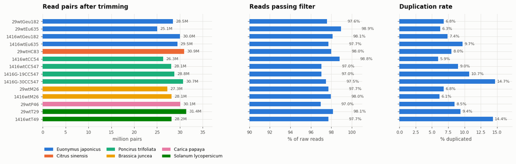

| sample | raw_pairs | trimmed_pairs | pct_passed | q30_after | gc | dup | mean_len |
| --- | --- | --- | --- | --- | --- | --- | --- |
| 29wtGeu182 | 29189985 | 28481977 | 97.57 | 93.77 | 45.16 | 6.79 | 142 |
| 29wtEu635 | 25328509 | 25059126 | 98.94 | 94.08 | 46.78 | 6.28 | 136 |
| 1416wtGeu182 | 30591322 | 30014222 | 98.11 | 93.84 | 46.18 | 7.38 | 139 |
| 1416wtEu635 | 30186550 | 29500441 | 97.73 | 94.12 | 45.73 | 9.69 | 142 |
| 29wtHC83 | 31536387 | 30900581 | 97.98 | 93.95 | 45.53 | 7.97 | 139 |
| 1416wtCC54 | 26664178 | 26345403 | 98.80 | 93.92 | 46.32 | 5.94 | 135 |
| 1416wtCC547 | 28932261 | 28071768 | 97.03 | 93.85 | 45.46 | 9.00 | 141 |
| 1416G-19CC547 | 29668797 | 28783101 | 97.01 | 93.62 | 44.00 | 10.72 | 142 |
| 1416G-30CC547 | 31480344 | 30687488 | 97.48 | 93.71 | 46.30 | 14.70 | 141 |
| 29wtM26 | 27908401 | 27271045 | 97.72 | 93.59 | 47.71 | 6.80 | 142 |
| 1416wtM26 | 28733013 | 28146193 | 97.96 | 93.55 | 47.96 | 6.13 | 142 |
| 29wtP46 | 31021187 | 30076241 | 96.95 | 93.63 | 46.06 | 8.47 | 141 |
| 29wtT29 | 31964272 | 31372463 | 98.15 | 93.91 | 44.09 | 9.37 | 142 |
| 1416wtT49 | 28852529 | 28191226 | 97.71 | 94.06 | 44.99 | 14.36 | 143 |

```python
rows = []
for s in ORDER:
    j = json.loads((ROOT / "01_trim" / f"{s}.fastp.json").read_text())
    b, a, fr = j["summary"]["before_filtering"], j["summary"]["after_filtering"], j["filtering_result"]
    rows.append(dict(sample=s,
                     raw_pairs=b["total_reads"] // 2, trimmed_pairs=a["total_reads"] // 2,
                     pct_passed=100 * fr["passed_filter_reads"] / b["total_reads"],
                     q30_after=100 * a["q30_rate"], gc=100 * a["gc_content"],
                     dup=100 * j["duplication"]["rate"],
                     mean_len=a["read1_mean_length"]))
trim = pd.DataFrame(rows).set_index("sample").loc[ORDER]

fig, axes = plt.subplots(1, 3, figsize=(13.5, 4.6), gridspec_kw={"width_ratios": [1.5, 1, 1]})
barh(axes[0], trim.index, trim["trimmed_pairs"] / 1e6, hcolors, "{:,.1f}M")
axes[0].set_title("Read pairs after trimming")
axes[0].set_xlabel("million pairs")
host_legend(axes[0])

for ax, col, title, xlab in [(axes[1], "pct_passed", "Reads passing filter", "% of raw reads"),
                             (axes[2], "dup", "Duplication rate", "% duplicated")]:
    barh(ax, trim.index, trim[col], [SERIES[0]] * len(trim), "{:.1f}%")
    ax.set_title(title); ax.set_xlabel(xlab)
    ax.set_yticklabels([])
axes[1].set_xlim(90, 101)
fig.suptitle("")
plt.tight_layout(); save(fig, "01_trimming"); plt.show()

trim.round(2)
```

## 3. Alignment to the combined reference

Each sample was aligned to a **combined index** — its host genome plus the *Agrobacterium* genome of the strain it carries — so a read competes between plant and bacterium in one pass instead of being assigned twice.

The alignment rate splits into two groups, and the split is about reference quality, not library quality:

- Hosts with a genome of their own species map at **82–96 %**.
- The four **Euonymus** samples map at **31–36 %**, because there is no *E. japonicus* assembly — the pipeline substitutes *E. europaeus* (`GCA_963580455.1`), a congener. Two thirds of those reads have nowhere to go.

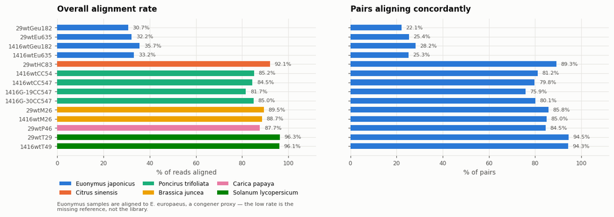

|  | total_pairs | conc_unique | conc_multi | disc | overall | conc_pct |
| --- | --- | --- | --- | --- | --- | --- |
| 29wtGeu182 | 28481977.0 | 5599461.0 | 693512.0 | 53298.0 | 30.68 | 22.09 |
| 29wtEu635 | 25059126.0 | 5481328.0 | 885325.0 | 39010.0 | 32.17 | 25.41 |
| 1416wtGeu182 | 30014222.0 | 6630376.0 | 1843774.0 | 55328.0 | 35.66 | 28.23 |
| 1416wtEu635 | 29500441.0 | 6287143.0 | 1170552.0 | 56533.0 | 33.20 | 25.28 |
| 29wtHC83 | 30900581.0 | 25771112.0 | 1819298.0 | 59012.0 | 92.12 | 89.29 |
| 1416wtCC54 | 26345403.0 | 20038041.0 | 1353209.0 | 49886.0 | 85.17 | 81.20 |
| 1416wtCC547 | 28071768.0 | 20126862.0 | 2279605.0 | 53286.0 | 84.45 | 79.82 |
| 1416G-19CC547 | 28783101.0 | 20488089.0 | 1349035.0 | 66031.0 | 81.66 | 75.87 |
| 1416G-30CC547 | 30687488.0 | 19543397.0 | 5031137.0 | 61768.0 | 85.01 | 80.08 |
| 29wtM26 | 27271045.0 | 21682882.0 | 1713069.0 | 80254.0 | 89.49 | 85.79 |
| 1416wtM26 | 28146193.0 | 22717254.0 | 1209016.0 | 85627.0 | 88.66 | 85.01 |
| 29wtP46 | 30076241.0 | 24379870.0 | 1044069.0 | 71344.0 | 87.74 | 84.53 |
| 29wtT29 | 31372463.0 | 27414296.0 | 2246773.0 | 48063.0 | 96.30 | 94.54 |
| 1416wtT49 | 28191226.0 | 23018185.0 | 3573635.0 | 39858.0 | 96.09 | 94.33 |

```python
def parse_hisat2(path):
    t = Path(path).read_text()
    g = lambda p: int(re.search(p, t).group(1))
    total = g(r"^(\d+) reads")
    return dict(
        total_pairs=total,
        conc_unique=g(r"(\d+) \([\d.]+%\) aligned concordantly exactly 1 time"),
        conc_multi=g(r"(\d+) \([\d.]+%\) aligned concordantly >1 times"),
        disc=g(r"(\d+) \([\d.]+%\) aligned discordantly 1 time"),
        overall=float(re.search(r"([\d.]+)% overall alignment rate", t).group(1)),
    )

aln = pd.DataFrame({s: parse_hisat2(ROOT / "02_align" / f"{s}.hisat2.log") for s in ORDER}).T
aln["conc_pct"] = 100 * (aln.conc_unique + aln.conc_multi) / aln.total_pairs

fig, axes = plt.subplots(1, 2, figsize=(12, 4.6))
barh(axes[0], aln.index, aln["overall"], hcolors, "{:.1f}%")
axes[0].set_title("Overall alignment rate"); axes[0].set_xlabel("% of reads aligned")
axes[0].set_xlim(0, 112); host_legend(axes[0])
note(axes[0], "Euonymus samples are aligned to E. europaeus, a congener proxy — the low rate is the\n"
              "missing reference, not the library.")

barh(axes[1], aln.index, aln["conc_pct"], [SERIES[0]] * len(aln), "{:.1f}%")
axes[1].set_title("Pairs aligning concordantly"); axes[1].set_xlabel("% of pairs")
axes[1].set_xlim(0, 112); axes[1].set_yticklabels([])
plt.tight_layout(); save(fig, "02_alignment"); plt.show()

aln.round(2)
```

## 4. The dual-RNA-seq split — and what the "bacterial" reads really are

This is the section that decides how the rest of the data can be used.

### 4a. The bacterial fraction is tiny

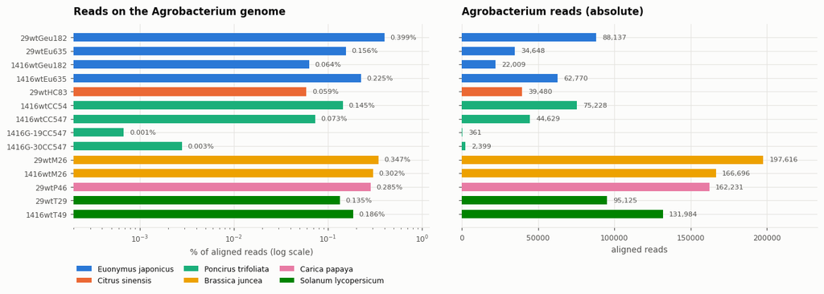

| sample | agro_reads | plant_reads | agro_frac | agro_pct |
| --- | --- | --- | --- | --- |
| 29wtGeu182 | 88137 | 21985264 | 0.0040 | 0.3993 |
| 29wtEu635 | 34648 | 22215722 | 0.0016 | 0.1557 |
| 1416wtGeu182 | 22009 | 34598014 | 0.0006 | 0.0636 |
| 1416wtEu635 | 62770 | 27776067 | 0.0023 | 0.2255 |
| 29wtHC83 | 39480 | 66699102 | 0.0006 | 0.0592 |
| 1416wtCC54 | 75228 | 51945285 | 0.0014 | 0.1446 |
| 1416wtCC547 | 44629 | 60910616 | 0.0007 | 0.0732 |
| 1416G-19CC547 | 361 | 53209315 | 0.0000 | 0.0007 |
| 1416G-30CC547 | 2399 | 85306462 | 0.0000 | 0.0028 |
| 29wtM26 | 197616 | 56811491 | 0.0035 | 0.3466 |
| 1416wtM26 | 166696 | 54964800 | 0.0030 | 0.3024 |
| 29wtP46 | 162231 | 56677059 | 0.0029 | 0.2854 |
| 29wtT29 | 95125 | 70398941 | 0.0013 | 0.1349 |
| 1416wtT49 | 131984 | 70849845 | 0.0019 | 0.1859 |

```python
frac = pd.read_csv(ROOT / "logs" / "mapping_fractions.tsv", sep="\t").set_index("sample").loc[ORDER]
frac["agro_pct"] = 100 * frac.agro_reads / (frac.agro_reads + frac.plant_reads)

fig, axes = plt.subplots(1, 2, figsize=(12.5, 4.6))
ax = axes[0]
y = np.arange(len(frac))
ax.barh(y, frac["agro_pct"], height=0.62, color=hcolors)
ax.set_yticks(y, frac.index); ax.invert_yaxis()
ax.set_xscale("log"); ax.set_xlim(2e-4, 1.2)
for yi, v in zip(y, frac["agro_pct"]):
    ax.text(v * 1.15, yi, f"{v:.3f}%", va="center", fontsize=7.5, color=INK2)
ax.set_title("Reads on the Agrobacterium genome"); ax.set_xlabel("% of aligned reads (log scale)")
clean(ax, "x"); host_legend(ax)

barh(axes[1], frac.index, frac["agro_reads"], hcolors, "{:,.0f}")
axes[1].set_title("Agrobacterium reads (absolute)"); axes[1].set_xlabel("aligned reads")
axes[1].set_yticklabels([])
plt.tight_layout(); save(fig, "03_agro_fraction"); plt.show()

frac.assign(agro_pct=frac.agro_pct.round(4))
```

### 4b. Those reads are almost all on one plasmid

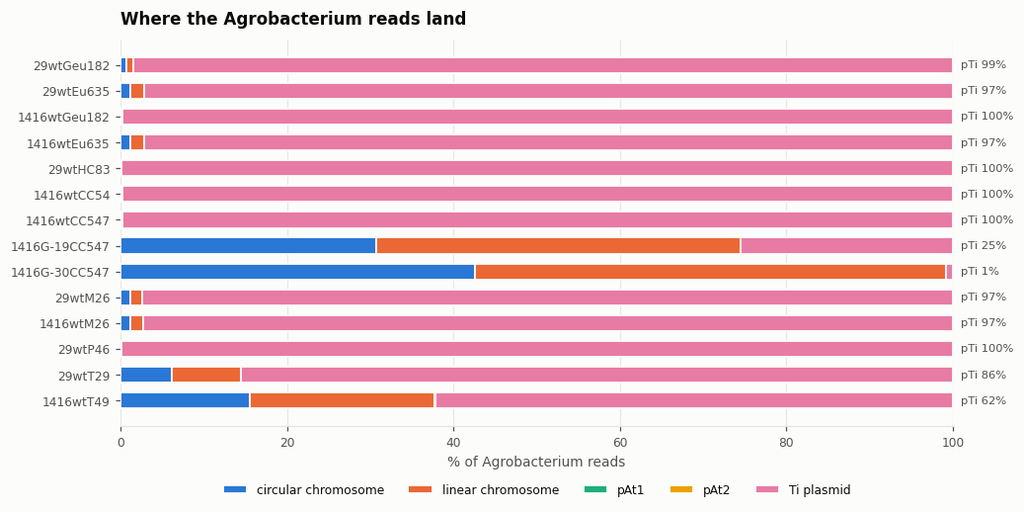

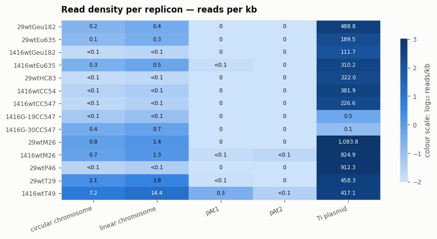

| ref | circ | lin | pAt1 | pAt2 | pTi |
| --- | --- | --- | --- | --- | --- |
| 29wtGeu182 | 0.61 | 0.84 | 0.00 | 0.0 | 98.55 |
| 29wtEu635 | 1.15 | 1.64 | 0.00 | 0.0 | 97.21 |
| 1416wtGeu182 | 0.08 | 0.11 | 0.00 | 0.0 | 99.81 |
| 1416wtEu635 | 1.17 | 1.60 | 0.00 | 0.0 | 97.22 |
| 29wtHC83 | 0.04 | 0.05 | 0.00 | 0.0 | 99.92 |
| 1416wtCC54 | 0.07 | 0.09 | 0.00 | 0.0 | 99.85 |
| 1416wtCC547 | 0.06 | 0.09 | 0.00 | 0.0 | 99.85 |
| 1416G-19CC547 | 30.75 | 43.77 | 0.00 | 0.0 | 25.48 |
| 1416G-30CC547 | 42.56 | 56.61 | 0.00 | 0.0 | 0.83 |
| 29wtM26 | 1.08 | 1.46 | 0.00 | 0.0 | 97.46 |
| 1416wtM26 | 1.11 | 1.55 | 0.00 | 0.0 | 97.34 |
| 29wtP46 | 0.03 | 0.04 | 0.00 | 0.0 | 99.94 |
| 29wtT29 | 6.15 | 8.23 | 0.00 | 0.0 | 85.62 |
| 1416wtT49 | 15.47 | 22.24 | 0.12 | 0.0 | 62.16 |

```python
def idxstats(sample):
    df = pd.read_csv(ROOT / "02_align" / f"{sample}.idxstats", sep="\t",
                     names=["ref", "length", "mapped", "unmapped"])
    return df[df.ref.str.startswith("agro_")]

REPL = ["circ", "lin", "pAt1", "pAt2", "pTi"]
REPL_LABEL = {"circ": "circular chromosome", "lin": "linear chromosome",
              "pAt1": "pAt1", "pAt2": "pAt2", "pTi": "Ti plasmid"}
rep_reads, rep_len = {}, {}
for s in ORDER:
    d = idxstats(s)
    key = d.ref.str.rsplit("_", n=1).str[-1]
    rep_reads[s] = d.groupby(key).mapped.sum().reindex(REPL).fillna(0)
    rep_len[s] = d.groupby(key).length.first().reindex(REPL)
rep_reads = pd.DataFrame(rep_reads).T.loc[ORDER]
rep_len = pd.DataFrame(rep_len).T.loc[ORDER]
rep_share = 100 * rep_reads.div(rep_reads.sum(axis=1), axis=0)

fig, ax = plt.subplots(figsize=(9.5, 4.8))
left = np.zeros(len(rep_share)); y = np.arange(len(rep_share))
for i, r in enumerate(REPL):
    ax.barh(y, rep_share[r], left=left, height=0.62, color=SERIES[i],
            edgecolor=SURFACE, linewidth=1.2, label=REPL_LABEL[r])   # surface gap between segments
    left += rep_share[r].values
ax.set_yticks(y, rep_share.index); ax.invert_yaxis()
ax.set_xlim(0, 100); ax.set_xlabel("% of Agrobacterium reads")
ax.set_title("Where the Agrobacterium reads land")
clean(ax, "x"); ax.legend(loc="upper center", bbox_to_anchor=(0.5, -0.12), ncols=5)
for yi, v in zip(y, rep_share["pTi"]):
    ax.text(101, yi, f"pTi {v:.0f}%", va="center", fontsize=7.5, color=INK2)
plt.tight_layout(); save(fig, "04_replicon_share"); plt.show()

# Coverage density makes the size difference explicit: reads per kb of replicon.
dens = (rep_reads / (rep_len / 1000)).replace([np.inf, -np.inf], np.nan)
fig, ax = plt.subplots(figsize=(8.5, 4.4))
m = ax.imshow(np.log10(dens.values + 0.01), cmap=SEQ, aspect="auto")
ax.set_xticks(range(len(REPL)), [REPL_LABEL[r] for r in REPL], rotation=20, ha="right")
ax.set_yticks(range(len(dens)), dens.index)
ax.set_title("Read density per replicon — reads per kb")
ax.grid(False)
for i in range(dens.shape[0]):
    for j in range(dens.shape[1]):
        v = dens.values[i, j]
        ax.text(j, i, f"{v:,.1f}" if v >= 0.1 else ("0" if v == 0 else "<0.1"),
                ha="center", va="center", fontsize=7,
                color="white" if np.log10(v + 0.01) > 0.7 else INK)
fig.colorbar(m, ax=ax, shrink=0.8, label="colour scale: log₁₀ reads/kb")
plt.tight_layout(); save(fig, "05_replicon_density"); plt.show()

rep_share.round(2)
```

### 4c. And within the Ti plasmid, they sit inside the T-DNA

Plotting each *Agrobacterium* gene's counts against its position on the Ti plasmid puts essentially all of the signal in one contiguous 3–22 kb block. In strain 1416 that block is annotated, and it is unambiguous:

| Gene | Annotation | Role |
| --- | --- | --- |
| `pTi.gene.5565` | Tryptophan 2-monooxygenase | *iaaM* — auxin synthesis |
| `pTi.gene.5564` | Indoleacetamide hydrolase | *iaaH* — auxin synthesis |
| `pTi.gene.5567` | Isopentenyl transferase | *ipt* — cytokinin synthesis |
| `pTi.gene.5571` | D-octopine dehydrogenase | *ocs* — opine synthesis |
| `pTi.gene.5563` | Agrocinopine synthase | *acs* — opine synthesis |
| `pTi.gene.5562` | RolB/RolC glucosidase family | *gene 5 / E* |

These are **T-DNA genes** — the segment *Agrobacterium* transfers into the plant nucleus. Once integrated they are transcribed by the plant's own polymerase, in plant cells, with plant promoters and polyadenylation. Those transcripts are in the host mRNA pool, and they align to the Ti plasmid because that is where the sequence came from.

So the "bacterial fraction" in section 4a is mostly **plant transcription of integrated T-DNA**, not the transcriptome of living bacteria. Three observations point the same way: the chromosome is silent while the T-DNA is not, the signal is confined to the T-DNA and stops at its borders, and the two mutants — the samples with essentially no T-DNA signal — are exactly the ones a disarmed or onc-mutant strain would produce.

Treat this as a strong reading of the coverage, not a settled fact: confirming it means checking strand and splicing at the T-DNA borders, and looking for plant-side polyadenylation.

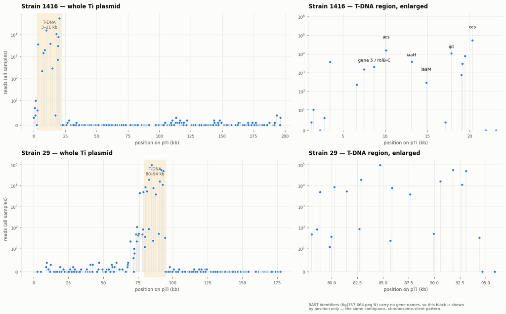

```python
def load_gff_genes(gff):
    rec = []
    for line in Path(gff).read_text().splitlines():
        if line.startswith("#") or "\tgene\t" not in line:
            continue
        f = line.split("\t")
        attr = dict(kv.split("=", 1) for kv in f[8].split(";") if "=" in kv)
        rec.append(dict(gene=attr.get("ID"), contig=f[0], start=int(f[3]), end=int(f[4]),
                        strand=f[6], name=attr.get("Name", "")))
    return pd.DataFrame(rec).set_index("gene")

STRAINS = {"1416": "strain_1416", "29": "strain_29"}
gff = {k: load_gff_genes(ROOT / "references" / "agrobacterium" / v / f"{v}.gff3")
       for k, v in STRAINS.items()}
mat = {k: pd.read_csv(ROOT / "04_matrix" / f"agro_{v}.tsv", sep="\t", index_col=0)
       for k, v in STRAINS.items()}

# Label only the handful of genes that carry the signal - never every point.
LABELS_1416 = {"agro_1416_pTi.gene.5562": "gene 5 / rolB-C",
               "agro_1416_pTi.gene.5563": "acs",
               "agro_1416_pTi.gene.5564": "iaaH",
               "agro_1416_pTi.gene.5565": "iaaM",
               "agro_1416_pTi.gene.5567": "ipt",
               "agro_1416_pTi.gene.5571": "ocs"}

# Two views per strain: the whole plasmid for context, and the T-DNA block on its
# own axis so the gene labels have room to sit without colliding.
fig, axes = plt.subplots(2, 2, figsize=(14, 8.6), gridspec_kw={"width_ratios": [1.4, 1]})
for row, strain in enumerate(["1416", "29"]):
    g, m = gff[strain], mat[strain]
    pti = g[g.contig == f"agro_{strain}_pTi"]
    tot = m.loc[m.index.intersection(pti.index)].sum(axis=1)
    d = pti.join(tot.rename("reads"), how="left").fillna({"reads": 0})
    hot = d.nlargest(8, "reads")
    lo, hi = hot.start.min() / 1000, hot.end.max() / 1000

    for col, ax in enumerate(axes[row]):
        x = d.start / 1000
        ax.vlines(x, 0, d.reads, color=GRID, linewidth=1)
        ax.scatter(x, d.reads, s=26, color=SERIES[0], zorder=3,
                   edgecolor=SURFACE, linewidth=1)        # surface ring on overlapping marks
        ax.set_yscale("symlog", linthresh=10)
        ax.set_xlabel("position on pTi (kb)")
        clean(ax, "y")
        if col == 0:
            ax.axvspan(lo - 1, hi + 1, color=SERIES[3], alpha=0.13, zorder=0)
            ax.set_title(f"Strain {strain} — whole Ti plasmid")
            ax.set_ylabel("reads (all samples)")
            ax.annotate(f"T-DNA\n{lo:.0f}–{hi:.0f} kb", xy=((lo + hi) / 2, 0.94),
                        xycoords=("data", "axes fraction"), ha="center", va="top",
                        fontsize=8, color=INK2)
        else:
            ax.set_xlim(lo - 2.5, hi + 2.5)
            ax.set_title(f"Strain {strain} — T-DNA region, enlarged")
            if strain == "1416":
                # stagger the labels: these genes sit within a few hundred bp of each other
                for n, (gene, lab) in enumerate(sorted(
                        LABELS_1416.items(), key=lambda kv: d.start.get(kv[0], 0))):
                    if gene not in d.index:
                        continue
                    r = d.loc[gene]
                    ax.annotate(lab, (r.start / 1000, max(r.reads, 1)),
                                textcoords="offset points", xytext=(0, 11 + 13 * (n % 2)),
                                ha="center", fontsize=8.5, color=INK,
                                arrowprops=dict(arrowstyle="-", color=GRID, linewidth=0.8,
                                                shrinkA=0, shrinkB=3))
                ax.margins(y=0.30)
                ax.set_ylim(bottom=0)
            else:
                note(ax, "RAST identifiers (fig|357.664.peg.N) carry no gene names, so this block is shown\n"
                         "by position only — the same contiguous, chromosome-silent pattern.", y=-0.22)
plt.tight_layout(); save(fig, "06_tdna_position"); plt.show()
```

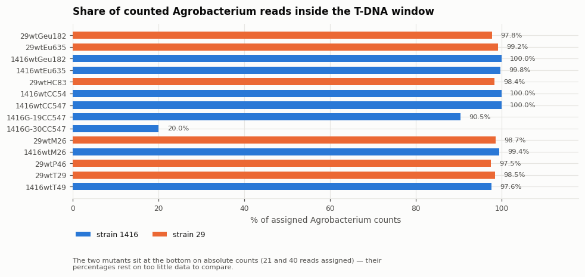

| sample | strain | agro_counted | tdna | pct |
| --- | --- | --- | --- | --- |
| 29wtGeu182 | 29 | 41479 | 40567 | 97.80 |
| 29wtEu635 | 29 | 16283 | 16150 | 99.18 |
| 1416wtGeu182 | 1416 | 6112 | 6111 | 99.98 |
| 1416wtEu635 | 1416 | 13491 | 13458 | 99.76 |
| 29wtHC83 | 29 | 18754 | 18458 | 98.42 |
| 1416wtCC54 | 1416 | 24748 | 24745 | 99.99 |
| 1416wtCC547 | 1416 | 15647 | 15647 | 100.00 |
| 1416G-19CC547 | 1416 | 21 | 19 | 90.48 |
| 1416G-30CC547 | 1416 | 40 | 8 | 20.00 |
| 29wtM26 | 29 | 93140 | 91888 | 98.66 |
| 1416wtM26 | 1416 | 16632 | 16540 | 99.45 |
| 29wtP46 | 29 | 78076 | 76111 | 97.48 |
| 29wtT29 | 29 | 38208 | 37640 | 98.51 |
| 1416wtT49 | 1416 | 28233 | 27561 | 97.62 |

```python
# Share of each sample's Agrobacterium reads that fall in the T-DNA window.
WINDOW = {"1416": (3_000, 22_000), "29": (78_000, 95_000)}
rows = []
for strain, m in mat.items():
    g = gff[strain]
    pti = g[g.contig == f"agro_{strain}_pTi"]
    lo, hi = WINDOW[strain]
    tdna = pti[(pti.start >= lo) & (pti.end <= hi)].index
    for s in m.columns:
        tot = m[s].sum()
        rows.append(dict(sample=s, strain=strain, agro_counted=tot,
                         tdna=m.loc[m.index.intersection(tdna), s].sum(),
                         pct=100 * m.loc[m.index.intersection(tdna), s].sum() / tot if tot else np.nan))
tdna = pd.DataFrame(rows).set_index("sample").reindex(ORDER).dropna(how="all")

fig, ax = plt.subplots(figsize=(9, 4.6))
barh(ax, tdna.index, tdna["pct"], [STRAIN_COLOR[s] for s in tdna["strain"]], "{:.1f}%")
ax.set_xlim(0, 118)
ax.set_title("Share of counted Agrobacterium reads inside the T-DNA window")
ax.set_xlabel("% of assigned Agrobacterium counts")
ax.legend(handles=[mpl.patches.Patch(facecolor=STRAIN_COLOR[k], label=f"strain {k}")
                   for k in ["1416", "29"]], loc="upper left", bbox_to_anchor=(0, -0.17),
          ncols=2, borderaxespad=0)
note(ax, "The two mutants sit at the bottom on absolute counts (21 and 40 reads assigned) — their\n"
         "percentages rest on too little data to compare.")
plt.tight_layout(); save(fig, "07_tdna_share"); plt.show()

tdna.round(2)
```

## 5. Counting

`featureCounts` assignment, per sample. The pattern follows annotation availability, not data quality:

- **Annotated hosts** (citrus, papaya, tomato) — 20–27 M pairs assigned.
- **Euonymus, mustard** — near-zero assignment. Their assemblies have no gene models, so reads align and then have nothing to be counted into. This is why `04_matrix/` holds no plant matrix for them.

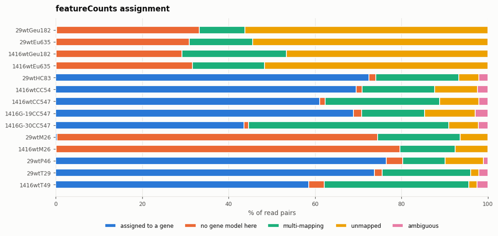

|  | assigned | no_features | multimapping | unmapped | ambiguity |
| --- | --- | --- | --- | --- | --- |
| 29wtGeu182 | 41479 | 10229222 | 3244758 | 17396180 | 548 |
| 29wtEu635 | 16283 | 8691729 | 4161329 | 15372396 | 89 |
| 1416wtGeu182 | 6112 | 10785104 | 8914653 | 17188550 | 551 |
| 1416wtEu635 | 13491 | 10695396 | 5647267 | 17470303 | 736 |
| 29wtHC83 | 26016399 | 567525 | 6892121 | 1664498 | 757606 |
| 1416wtCC54 | 20848519 | 402862 | 5044408 | 2957122 | 720722 |
| 1416wtCC547 | 21328245 | 453141 | 9249649 | 3173861 | 739936 |
| 1416G-19CC547 | 22019362 | 613768 | 4640862 | 3756112 | 940005 |
| 1416G-30CC547 | 20676094 | 499046 | 22013222 | 3253989 | 1042474 |
| 29wtM26 | 93140 | 23351408 | 6017943 | 2022460 | 352 |
| 1416wtM26 | 16632 | 24531350 | 3960391 | 2319193 | 1023 |
| 29wtP46 | 24595498 | 1219395 | 3168104 | 2835077 | 337374 |
| 29wtT29 | 26918739 | 683062 | 7467981 | 700193 | 749005 |
| 1416wtT49 | 21526646 | 1338727 | 12281863 | 699181 | 936149 |

```python
def fc_summary(sample):
    d = pd.read_csv(ROOT / "03_counts" / f"{sample}.txt.summary", sep="\t",
                    index_col=0).iloc[:, 0]
    return dict(assigned=d.get("Assigned", 0),
                no_features=d.get("Unassigned_NoFeatures", 0),
                multimapping=d.get("Unassigned_MultiMapping", 0),
                unmapped=d.get("Unassigned_Unmapped", 0),
                ambiguity=d.get("Unassigned_Ambiguity", 0))

fc = pd.DataFrame({s: fc_summary(s) for s in ORDER}).T.loc[ORDER]
fc_pct = 100 * fc.div(fc.sum(axis=1), axis=0)

CATS = [("assigned", "assigned to a gene"), ("no_features", "no gene model here"),
        ("multimapping", "multi-mapping"), ("unmapped", "unmapped"),
        ("ambiguity", "ambiguous")]
fig, ax = plt.subplots(figsize=(10, 4.8))
left = np.zeros(len(fc_pct)); y = np.arange(len(fc_pct))
for i, (c, lab) in enumerate(CATS):
    ax.barh(y, fc_pct[c], left=left, height=0.62, color=SERIES[i],
            edgecolor=SURFACE, linewidth=1.2, label=lab)
    left += fc_pct[c].values
ax.set_yticks(y, fc_pct.index); ax.invert_yaxis()
ax.set_xlim(0, 100); ax.set_xlabel("% of read pairs")
ax.set_title("featureCounts assignment")
clean(ax, "x"); ax.legend(loc="upper center", bbox_to_anchor=(0.5, -0.12), ncols=5)
plt.tight_layout(); save(fig, "08_featurecounts"); plt.show()

fc
```

## 6. Expression matrices

Five matrices were written. Their usability differs by two orders of magnitude, so it is worth stating plainly before any of them is plotted.

```python
mats = {p.stem: pd.read_csv(p, sep="\t", index_col=0)
        for p in sorted((ROOT / "04_matrix").glob("*.tsv"))}
summary = pd.DataFrame([
    dict(matrix=k, genes=len(m), samples=m.shape[1],
         median_library=int(m.sum().median()),
         median_genes_detected=int((m > 0).sum().median()),
         pct_genes_detected=round(100 * (m > 0).sum().median() / len(m), 1))
    for k, m in mats.items()]).set_index("matrix")
summary
```

| matrix | genes | samples | median_library | median_genes_detected | pct_genes_detected |
| --- | --- | --- | --- | --- | --- |
| agro_strain_1416 | 5758 | 8 | 14569 | 13 | 0.2 |
| agro_strain_29 | 5836 | 6 | 39843 | 26 | 0.5 |
| plant_carica_papaya | 20000 | 1 | 24517422 | 18193 | 91.0 |
| plant_citrus_sinensis | 28080 | 5 | 21312598 | 19880 | 70.8 |
| plant_solanum_lycopersicum | 40019 | 2 | 24189472 | 26073 | 65.2 |

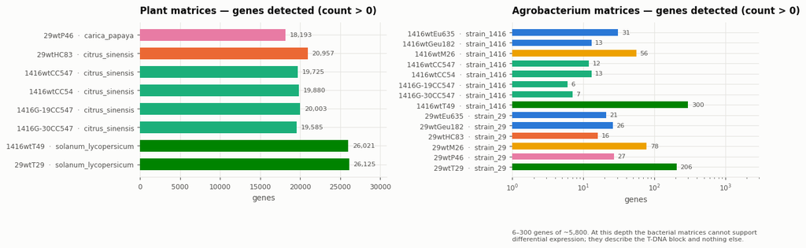

```python
plant = {k: v for k, v in mats.items() if k.startswith("plant_")}
agro = {k: v for k, v in mats.items() if k.startswith("agro_")}

fig, axes = plt.subplots(1, 2, figsize=(12.5, 4.4))
for ax, (group, title) in zip(axes, [(plant, "Plant matrices"), (agro, "Agrobacterium matrices")]):
    labs, vals, cols = [], [], []
    for k, m in group.items():
        for s in m.columns:
            labs.append(f"{s}  ·  {k.split('_', 1)[1]}")
            vals.append((m[s] > 0).sum())
            cols.append(HOST_COLOR.get(meta.loc[s, "host_species"], SERIES[0]))
    is_agro = group is agro
    barh(ax, labs, vals, cols, "{:,.0f}", log=is_agro)
    if is_agro:
        ax.set_xscale("log"); ax.set_xlim(1, 3e3)
    ax.set_title(f"{title} — genes detected (count > 0)")
    ax.set_xlabel("genes")
note(axes[1], "6–300 genes of ~5,800. At this depth the bacterial matrices cannot support\n"
              "differential expression; they describe the T-DNA block and nothing else.")
plt.tight_layout(); save(fig, "09_genes_detected"); plt.show()
```

### 6a. Plant expression

The citrus matrix is the only one with enough samples to look at structure: one native *C. sinensis* gall (`29wtHC83`) plus four *Poncirus trifoliata* galls mapped onto the sweet-orange annotation, since *Poncirus* has no gene models of its own.

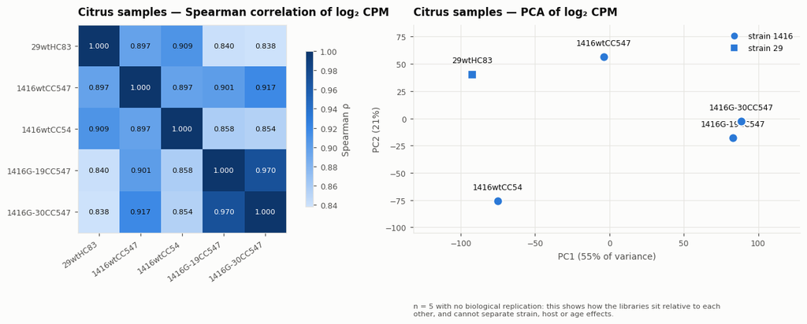

```python
def cpm_log(m, min_count=10):
    keep = m[(m.sum(axis=1) >= min_count)]
    return np.log2(1e6 * keep / keep.sum() + 1)

cit = plant.get("plant_citrus_sinensis")
lc = cpm_log(cit)
corr = lc.corr(method="spearman")

fig, axes = plt.subplots(1, 2, figsize=(13, 5))
ax = axes[0]
m = ax.imshow(corr.values, cmap=SEQ, vmin=corr.values.min(), vmax=1)
ax.set_xticks(range(len(corr)), corr.columns, rotation=35, ha="right")
ax.set_yticks(range(len(corr)), corr.index)
ax.grid(False); ax.set_title("Citrus samples — Spearman correlation of log₂ CPM")
for i in range(len(corr)):
    for j in range(len(corr)):
        v = corr.values[i, j]
        ax.text(j, i, f"{v:.3f}", ha="center", va="center", fontsize=7.5,
                color="white" if v > corr.values.min() + 0.6 * (1 - corr.values.min()) else INK)
fig.colorbar(m, ax=ax, shrink=0.75, label="Spearman ρ")

# PCA: few points, so direct-label every one and keep a single hue - no legend needed.
ax = axes[1]
X = lc.T.values
X = X - X.mean(0)
U, S, Vt = np.linalg.svd(X, full_matrices=False)
pcs = U * S
var = 100 * S**2 / (S**2).sum()
marker = {"1416": "o", "29": "s"}
for i, s in enumerate(lc.columns):
    ax.scatter(pcs[i, 0], pcs[i, 1], s=90, color=SERIES[0],
               marker=marker[str(meta.loc[s, "strain"])], edgecolor=SURFACE, linewidth=1.5, zorder=3)
    ax.annotate(s, (pcs[i, 0], pcs[i, 1]), textcoords="offset points", xytext=(0, 12),
                ha="center", fontsize=8, color=INK)
ax.set_xlabel(f"PC1 ({var[0]:.0f}% of variance)"); ax.set_ylabel(f"PC2 ({var[1]:.0f}%)")
ax.set_title("Citrus samples — PCA of log₂ CPM")
ax.margins(0.22); clean(ax, "both")
ax.legend(handles=[mpl.lines.Line2D([], [], marker=marker[k], linestyle="", color=SERIES[0],
                                    markeredgecolor=SURFACE, label=f"strain {k}") for k in marker],
          loc="best")
note(ax, "n = 5 with no biological replication: this shows how the libraries sit relative to each\n"
         "other, and cannot separate strain, host or age effects.")
plt.tight_layout(); save(fig, "10_citrus_structure"); plt.show()
```

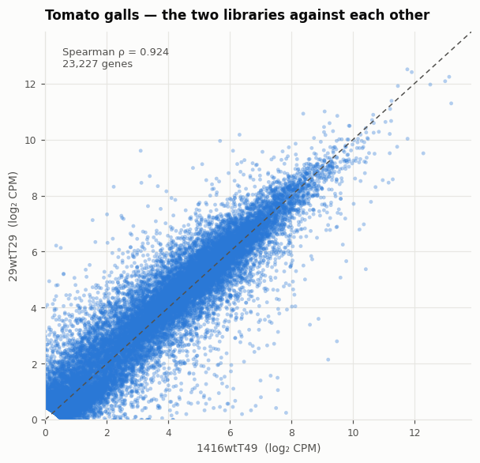

```python
# Tomato has two samples, papaya one - enough for a shared-expression check only.
tom = plant.get("plant_solanum_lycopersicum")
lt = cpm_log(tom)
fig, ax = plt.subplots(figsize=(5.6, 5.4))
ax.scatter(lt.iloc[:, 0], lt.iloc[:, 1], s=10, color=SERIES[0], alpha=0.35,
           edgecolor="none", rasterized=True)
lim = [0, max(lt.max()) * 1.05]
ax.plot(lim, lim, color=INK2, linewidth=1, linestyle=(0, (4, 3)))
ax.set_xlim(lim); ax.set_ylim(lim)
ax.set_xlabel(f"{lt.columns[0]}  (log₂ CPM)"); ax.set_ylabel(f"{lt.columns[1]}  (log₂ CPM)")
ax.set_title("Tomato galls — the two libraries against each other")
clean(ax, "both")
r = lt.corr(method="spearman").iloc[0, 1]
ax.text(0.04, 0.96, f"Spearman ρ = {r:.3f}\n{len(lt):,} genes", transform=ax.transAxes,
        va="top", fontsize=8.5, color=INK2)
plt.tight_layout(); save(fig, "11_tomato_pair"); plt.show()
```

### 6b. Bacterial expression

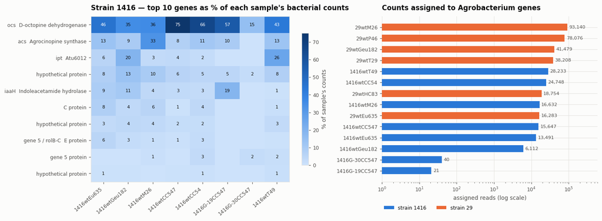

```python
fig, axes = plt.subplots(1, 2, figsize=(13.5, 5), gridspec_kw={"width_ratios": [1.15, 1]})
strain, m = "1416", mat["1416"]
top = m.loc[m.sum(axis=1).nlargest(10).index]
share = 100 * top / m.sum()
names = gff[strain].loc[top.index, "name"].str[:34]
labels = [f"{LABELS_1416.get(g, '')}  {n}".strip() for g, n in zip(top.index, names)]

ax = axes[0]
im = ax.imshow(share.values, cmap=SEQ, aspect="auto", vmin=0, vmax=share.values.max())
ax.set_xticks(range(share.shape[1]), share.columns, rotation=40, ha="right")
ax.set_yticks(range(len(labels)), labels)
ax.grid(False)
ax.set_title("Strain 1416 — top 10 genes as % of each sample's bacterial counts")
for i in range(share.shape[0]):
    for j in range(share.shape[1]):
        v = share.values[i, j]
        if v >= 0.5:
            ax.text(j, i, f"{v:.0f}", ha="center", va="center", fontsize=7,
                    color="white" if v > 0.55 * share.values.max() else INK)
fig.colorbar(im, ax=ax, shrink=0.8, label="% of sample's counts")

ax = axes[1]
labs, vals, cols = [], [], []
for strain, m in mat.items():
    for s in m.columns:
        labs.append(s); vals.append(max(m[s].sum(), 0.5)); cols.append(STRAIN_COLOR[strain])
o = np.argsort(-np.array(vals))
ax.set_xscale("log")
barh(ax, [labs[i] for i in o], [vals[i] for i in o], [cols[i] for i in o], "{:,.0f}", log=True)
ax.set_xlim(1, 6e5)
ax.set_title("Counts assigned to Agrobacterium genes"); ax.set_xlabel("assigned reads (log scale)")
ax.legend(handles=[mpl.patches.Patch(facecolor=STRAIN_COLOR[k], label=f"strain {k}")
                   for k in ["1416", "29"]], loc="upper left", bbox_to_anchor=(0, -0.13),
          ncols=2, borderaxespad=0)
plt.tight_layout(); save(fig, "12_agro_top_genes"); plt.show()
```

## 7. Where this leaves the experiment

**Usable now**

- Host transcriptomes for citrus (5), tomato (2) and papaya (1) — 20–27 M assigned pairs each, 65–91 % of gene models detected. Solid libraries.
- T-DNA expression in the gall, per sample, as a quantitative readout of how strongly the integrated oncogenes are transcribed.

**Worth checking next**

- Confirm the T-DNA reading — strand and splicing at the borders, plant-side polyadenylation — and confirm the library preparation against the sequencing provider's record, since the protocol written down in the repo describes the 2019 reference paper rather than these galls.
- `1416G-19CC547` and `1416G-30CC547` show essentially no T-DNA signal. If those mutants are disarmed or onc-region mutants that is the expected result and a useful internal control; worth confirming against the strain records.
- A Liftoff annotation from *C. sinensis* onto *P. trifoliata* would let the four CC samples be counted on their own genome instead of a cross-species proxy.